# RUV_FF_vs_Mal_all_groups_Salmon

### 5.3.1 Comparison between the downregulated genes

```r
I_down<- intersect(rownames(downresSig_Salmon), rownames(Topgenes_sfactor_edgeR_0.1_1_down$table))
length(I_down)
```

[1] 111

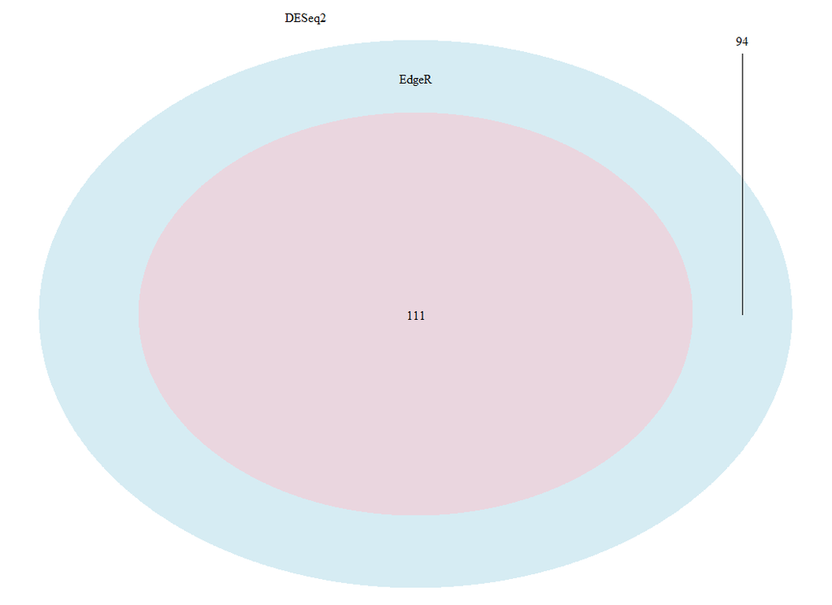

```r
grid.newpage()
draw.pairwise.venn(nrow(downresSig_Salmon), nrow(Topgenes_sfactor_edgeR_0.1_1_down$table), length(I_down), category = c("DESeq2", "EdgeR"), lty = rep("blank",
    2), fill = c("light blue", "pink"), alpha = rep(0.5, 2), cat.pos = c(-15,
    0), cat.dist = rep(0.025, 2), title= "Down regulated genes according to DESeq and/or EdgeR")
```

### 5.3.2 The upregulated genes

```r
I_up<- intersect(rownames(upresSig_Salmon), rownames(Topgenes_sfactor_edgeR_0.1_1_up$table))
length(I_up)
```

[1] 85

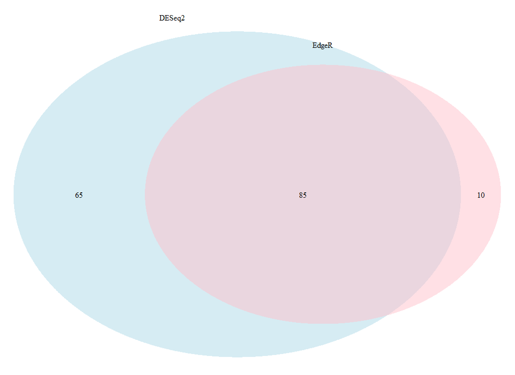

```r
grid.newpage()
draw.pairwise.venn(nrow(upresSig_Salmon), nrow(Topgenes_sfactor_edgeR_0.1_1_up$table), length(I_up), category = c("DESeq2", "EdgeR"), lty = rep("blank",
    2), fill = c("light blue", "pink"), alpha = rep(0.5, 2), cat.pos = c(-15,
    0), cat.dist = rep(0.025, 2), title= "up DE genes from DESeq and EdgeR")
```

## 5.4 Get the list of the genes that are in both DESeq2 and edgeR DE genes.

```r
head(I_total)
```

[1] “ENSSSCG00000008959” “ENSSSCG00000004454” “ENSSSCG00000002009” [4] “ENSSSCG00000007507” “ENSSSCG00000029592” “ENSSSCG00000035347”

```r
Salmon_intersect<-gene_names[rownames(gene_names) %in% I_total, ]
saveRDS(Salmon_intersect,file = file.path(output_dir,sprintf("FF_vs_Mal_all_Salmon_intersect_w_outliers.RDS")))
```

## 5.5 Including Plots